# Contents:

Q1. Import Libraries

Q2. Read the Data as Dataframe

Q3a. Shape of Data

Q3b. Data Type of Attributes

Q3c. Checking the presence of missing values

Q3d. 5 point summary of numerical attributes

Q3e. Distribution of ‘bmi’, ‘age’ and ‘charges’ columns

Q3f. Measure of skewness of ‘bmi’, ‘age’ and ‘charges’ columns

Q3g. Checking the presence of outliers in ‘bmi’, ‘age’ and ‘charges

Q3h. Distribution of categorical columns

Q3i. Pair plot that includes all the columns of the data frame

Q4a. Do charges of people who smoke differ significantly from the people who don't

Q4b. Does bmi of males differ significantly from that of females

Q4c. Is the proportion of smokers significantly different in different genders

Q4d. Is the distribution of bmi across women with no children, one child and two children, the same

# Q1. Import Libraries

```python
# Import basic libraries

import numpy as np
import pandas as pd
from math import *

# Import libraries for Visualisation

import matplotlib.pyplot as plt
import seaborn as sns
sns.set(color_codes=True)
%matplotlib inline

# Import statistical libraries

import scipy.stats as st
from scipy.stats import ttest_1samp, ttest_ind, norm, t


import statsmodels.api         as     sm
from   statsmodels.formula.api import ols
from statsmodels.stats.proportion import proportions_ztest

# Import label encoder

from sklearn.preprocessing import LabelEncoder

# To see multiple outputs together

from IPython.core.interactiveshell import InteractiveShell
InteractiveShell.ast_node_interactivity = "all"
```

# Q2. Read the Data as Dataframe

```python
# Reading data as a dataframe

insurance = pd.read_csv('insurance.csv')

# Perform a 'head' to look into the data and understand the variables

insurance.head()
```

|  | age | sex | bmi | children | smoker | region | charges |
| --- | --- | --- | --- | --- | --- | --- | --- |
| 0 | 19 | female | 27.900 | 0 | yes | southwest | 16884.92400 |
| 1 | 18 | male | 33.770 | 1 | no | southeast | 1725.55230 |
| 2 | 28 | male | 33.000 | 3 | no | southeast | 4449.46200 |
| 3 | 33 | male | 22.705 | 0 | no | northwest | 21984.47061 |
| 4 | 32 | male | 28.880 | 0 | no | northwest | 3866.85520 |

# Q3a. Shape of Data

```python
insurance.shape
```

```
(1338, 7)
```

The data-set has 1338 rows (observations) and 7 columns (attributes)

# Q3b. Data Type of Attributes

```python
insurance.info()
```

```
<class 'pandas.core.frame.DataFrame'>
RangeIndex: 1338 entries, 0 to 1337
Data columns (total 7 columns):
 #   Column    Non-Null Count  Dtype
---  ------    --------------  -----
 0   age       1338 non-null   int64
 1   sex       1338 non-null   object
 2   bmi       1338 non-null   float64
 3   children  1338 non-null   int64
 4   smoker    1338 non-null   object
 5   region    1338 non-null   object
 6   charges   1338 non-null   float64
dtypes: float64(2), int64(2), object(3)
memory usage: 73.3+ KB
```

- The dataset has 2 float64 and 2 int64 type attributes. They are 'bmi', 'charges' and 'children', 'age' respectively. These are all numeric variables.
- The dataset has 3 object type attributes viz 'sex', 'smoker' and 'region'. These are categorical variables.

# Q3c. Checking the presence of missing values

The above analysis on attribute type of the data using info() function has already shown us that there is no missing values in any of the attributes in the data. However, we can also use the isnull() function to directly analyse the missing values. Many times garbage data, e.g. symbols as a value etc may indicate missing values; however, python will treat them as non-missing. Hence, when we use isnull() function it will only return the information based on the ones recognised as missing values.

```python
# number of missing values in each of the attributes
pd.DataFrame( insurance.isnull().sum(), columns= ['Number of missing values'])
```

|  | Number of missing values |
| --- | --- |
| age | 0 |
| sex | 0 |
| bmi | 0 |
| children | 0 |
| smoker | 0 |
| region | 0 |
| charges | 0 |

There is no missing values in any of the attributes.

# Q3d. 5 point summary of numerical attributes

The 5 point summary helps describe the center, spread and shape of data. The five summary statistics are as follows,

- Minimum
- Q1 or the 1st quartile
- Q2 or the 2nd quartile or median
- Q3 or the 3rd quartile
- Maximum

and in Python is computed by the function describe()

```python
insurance.describe()
```

|  | age | bmi | children | charges |
| --- | --- | --- | --- | --- |
| count | 1338.000000 | 1338.000000 | 1338.000000 | 1338.000000 |
| mean | 39.207025 | 30.663397 | 1.094918 | 13270.422265 |
| std | 14.049960 | 6.098187 | 1.205493 | 12110.011237 |
| min | 18.000000 | 15.960000 | 0.000000 | 1121.873900 |
| 25% | 27.000000 | 26.296250 | 0.000000 | 4740.287150 |
| 50% | 39.000000 | 30.400000 | 1.000000 | 9382.033000 |
| 75% | 51.000000 | 34.693750 | 2.000000 | 16639.912515 |
| max | 64.000000 | 53.130000 | 5.000000 | 63770.428010 |

1. Age : The minimum and maximum age of customers from data are 18 and 64 respectively. With mean and median being close (both around 39), 'age' may be symmetric.
2. BMI : With mean and median being close (around 30) 'bmi' seems to be symmetric.
3. Children : The minimum number of children a customer has is 0 and the maximum is 5.
4. Charges : Since mean > median, 'charges' seems to be right-skewed or positive skewed.

To comment on the distributions of all the above attributes we need to analyse further and the obseravtions made are only based on 5 point summary values.

# Q3e. Distribution of ‘bmi’, ‘age’ and ‘charges’ columns.

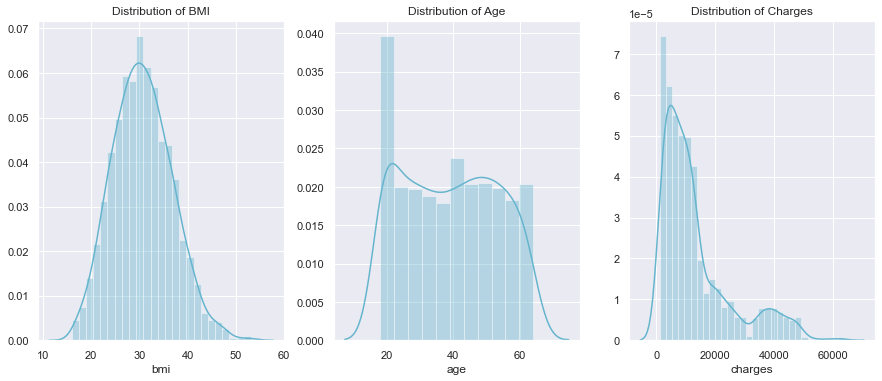

```python
sns.set(rc={"figure.figsize": (15, 20)});

plt.subplot(3,3,1);
ax=sns.distplot(insurance.bmi, color='c');
ax.set_title('Distribution of BMI');


plt.subplot(3,3,2);
ax=sns.distplot(insurance.age, color='c');
ax.set_title('Distribution of Age');

plt.subplot(3,3,3);
ax=sns.distplot(insurance.charges, color='c');
ax.set_title('Distribution of Charges');
```

# Q3f. Measure of skewness of ‘bmi’, ‘age’ and ‘charges’ columns

Skewness is the extent to which the data values are not symmetrical around the mean.

$$skeweness = \frac{\sum_{i=1}^{n}(x_i - \bar{x})^3} {(n-1)*\sigma^3}$$

• Mean > Median : Positive or right skewed distribution

• Mean = Median: Zero skewness or symmetrical distribution

• Mean < Median : Negative or left skewed distribution

```python
pd.DataFrame([st.skew(insurance['bmi']),
              st.skew(insurance['age']),
              st.skew(insurance['charges'])],
             index=['BMI','Age','Charges'],columns=['Skewness'])
```

|  | Skewness |
| --- | --- |
| BMI | 0.283729 |
| Age | 0.055610 |
| Charges | 1.514180 |

- BMI has a skewness of 0.28. It has a very less positive skewness. In relation with previous results we say it has a symmetric distribution.
- Age has a skewness of 0.05 which is almost zero. Together with the study of distribution of 'Age', we say it has an uniform distribution.
- Charges has a skewness of 1.51. This is a postive skewness or a right-skewed distribution.

# Q3g. Checking the presence of outliers in ‘bmi’, ‘age’ and ‘charges

Presence of outliers can be detected by Box-plot diagrams.

Box-plots are diagrams to reprsent the 5 point summary of attributes i.e. the minimum, maximum, 1st Quartile, 2nd Quartile (also called Median) and 3rd Quartile.

The end points of the diagram are called called whiskers. The lower whisker represents the value Q1 - 1.5IQR, while the upper whisker represents the value Q3 + 1.5IQR where Q1 and Q3 are the 1st and 3rd Quartiles respectively and IQR is the Inter Quartile Range is the size of the box and equals Q3-Q1.

Any point beyond these whiskers is termed as an outlier. An outlier could be both towards the lower as well as higher side of the attribute.

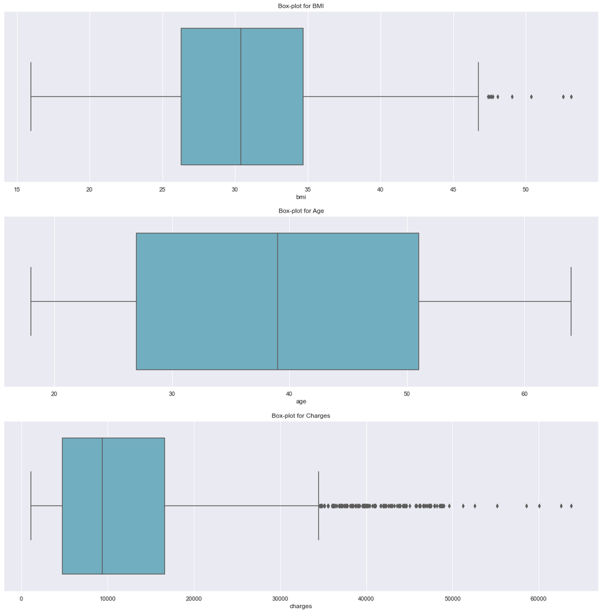

```python
sns.set(rc={"figure.figsize": (20, 20)});

plt.subplot(3,1,1);
sns.boxplot(x= insurance.bmi, color='c');
plt.title('Box-plot for BMI');

plt.subplot(3,1,2);
sns.boxplot(x= insurance.age, color='c');
plt.title('Box-plot for Age');

plt.subplot(3,1,3);
sns.boxplot(x= insurance.charges, color='c');
plt.title('Box-plot for Charges');
```

- The attribute 'age' does not have any outlier. However, both 'bmi' and 'charges' have outliers towards the higher sides.
- Attribute 'bmi' has only few outliers but 'charges' has quite a lot of outliers.

Now, we proceed to find the number of outliers using the Inter Quartile Range.

```python
# Defining IQR for BMI and Charges
Q1_bmi = insurance['bmi'].quantile(0.25)
Q3_bmi = insurance['bmi'].quantile(0.75)
IQR_bmi = Q3_bmi - Q1_bmi

Q1_charges = insurance['charges'].quantile(0.25)
Q3_charges = insurance['charges'].quantile(0.75)
IQR_charges = Q3_charges - Q1_charges

# Getting the outliers for BMI and Charges
# Though box-plots show outliers towards the higher side, conditioning on the lower side of IQR as well to ensure we don't miss any


out_bmi = np.where((insurance['bmi'] < (Q1_bmi - 1.5 * IQR_bmi)) | (insurance['bmi'] > (Q3_bmi + 1.5 * IQR_bmi)))

out_charges = np.where((insurance['charges'] < (Q1_charges - 1.5 * IQR_charges)) | (insurance['charges'] > (Q3_charges + 1.5 * IQR_charges)))

print('No of outliers for BMI is',np.size(out_bmi))
print()
print('No of outliers for Charges is',np.size(out_charges))
```

```
No of outliers for BMI is 9

No of outliers for Charges is 139
```

# Q3h. Distribution of categorical columns (include children)

```python
# Function to add percentage values to chart

def add_percentage(plot, feature):
    total = len(feature)
    for p in ax.patches:
        percentage = '{:.1f}%'.format(100 * p.get_height()/total)
        x = p.get_x() + p.get_width() / 2 - 0.05
        y = p.get_y() + p.get_height()
        ax.annotate(percentage, (x, y))
    plt.show();
```

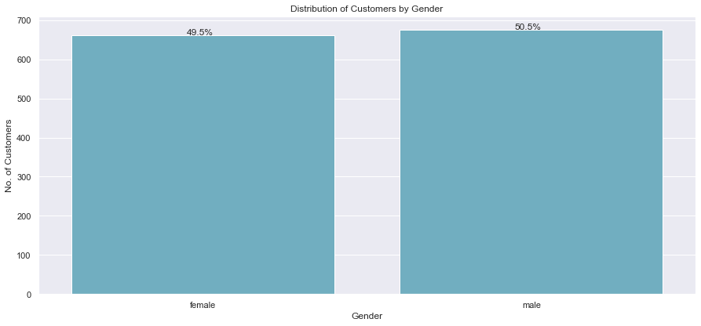

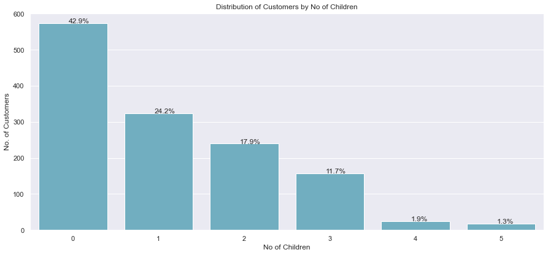

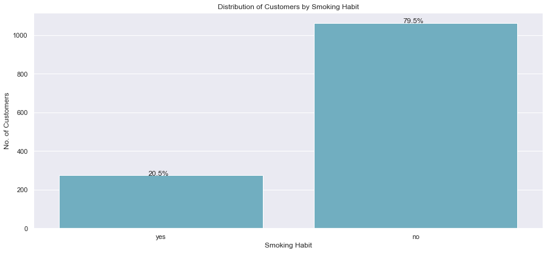

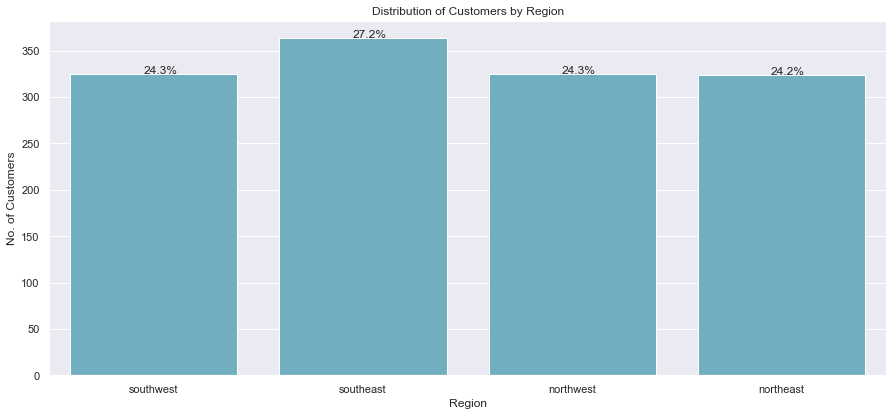

```python
sns.set(rc={"figure.figsize": (15, 30)});
plt.subplot(4,1,1)

ax=sns.countplot(insurance['sex'], color='c');
plt.xlabel('Gender');
plt.ylabel('No. of Customers');
plt.title('Distribution of Customers by Gender');
add_percentage(ax,insurance.sex);


plt.subplot(4,1,2)

ax=sns.countplot(insurance['children'], color='c');
plt.xlabel('No of Children');
plt.ylabel('No. of Customers');
plt.title('Distribution of Customers by No of Children');
add_percentage(ax,insurance.children);

plt.subplot(4,1,3)

ax=sns.countplot(insurance['smoker'], color='c');
plt.xlabel('Smoking Habit');
plt.ylabel('No. of Customers');
plt.title('Distribution of Customers by Smoking Habit');
add_percentage(ax,insurance.smoker);

plt.subplot(4,1,4)

ax=sns.countplot(insurance['region'], color='c');
plt.xlabel('Region');
plt.ylabel('No. of Customers');
plt.title('Distribution of Customers by Region');
add_percentage(ax,insurance.region);
```

- There are almost equal number of male and female customers.
- While most customers (43%) do not have a child, only 3% have 4-5 children. 24%, ~18% and ~12% have respectively one, two and three children.
- 79.5% of the customers are non-smokers.
- The number of customers are uniformly distributed across the 4 regions with Southeast (27%) marginally ahead of other regions.

# Q3i. Pair plot that includes all the columns of the data frame

```python
# One Hot Encoding of categorical variables and basic data checks

labelencoder = LabelEncoder()

insurance_enc = insurance.copy()

insurance_enc['Region'] = labelencoder.fit_transform(insurance.region)
insurance_enc['Sex'] = labelencoder.fit_transform(insurance.sex)
insurance_enc['Smoking_habit'] = labelencoder.fit_transform(insurance.smoker)

insurance_enc.head()
insurance_enc.info()
```

|  | age | sex | bmi | children | smoker | region | charges | Region | Sex | Smoking_habit |
| --- | --- | --- | --- | --- | --- | --- | --- | --- | --- | --- |
| 0 | 19 | female | 27.900 | 0 | yes | southwest | 16884.92400 | 3 | 0 | 1 |
| 1 | 18 | male | 33.770 | 1 | no | southeast | 1725.55230 | 2 | 1 | 0 |
| 2 | 28 | male | 33.000 | 3 | no | southeast | 4449.46200 | 2 | 1 | 0 |
| 3 | 33 | male | 22.705 | 0 | no | northwest | 21984.47061 | 1 | 1 | 0 |
| 4 | 32 | male | 28.880 | 0 | no | northwest | 3866.85520 | 1 | 1 | 0 |

```
<class 'pandas.core.frame.DataFrame'>
RangeIndex: 1338 entries, 0 to 1337
Data columns (total 10 columns):
 #   Column         Non-Null Count  Dtype
---  ------         --------------  -----
 0   age            1338 non-null   int64
 1   sex            1338 non-null   object
 2   bmi            1338 non-null   float64
 3   children       1338 non-null   int64
 4   smoker         1338 non-null   object
 5   region         1338 non-null   object
 6   charges        1338 non-null   float64
 7   Region         1338 non-null   int32
 8   Sex            1338 non-null   int32
 9   Smoking_habit  1338 non-null   int32
dtypes: float64(2), int32(3), int64(2), object(3)
memory usage: 89.0+ KB
```

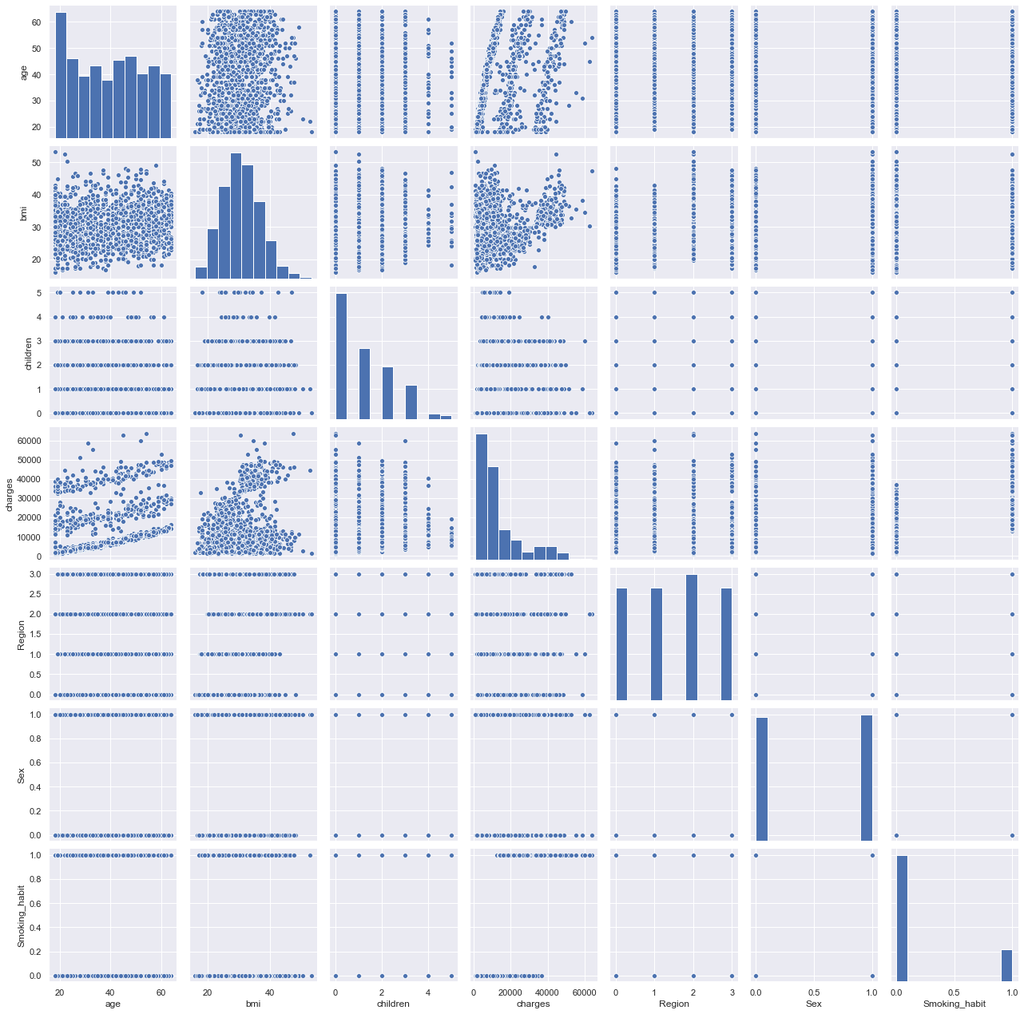

```python
sns.pairplot(data=insurance_enc);
```

- Smoking habit of customers and charges seem to have a strong relationship. Charges billed for smokers are higher than that billed for non-smokers
- There is a postive relationship between age and charges i.e. with age the medical costs increases. However, this trend seems to appear in 3 distinct clusters for which the overall postive relationship between age and charges seem to be low. Such clusters could be due to presence of some factor which is not evident from the data or may need deeper analysis. Example : Some disease D1 could be more expensive than disease D2. Hence a younger customer with D1 is being charged higher than an older customer for D2.

# Q4a. Do charges of people who smoke differ significantly from the people who don't?

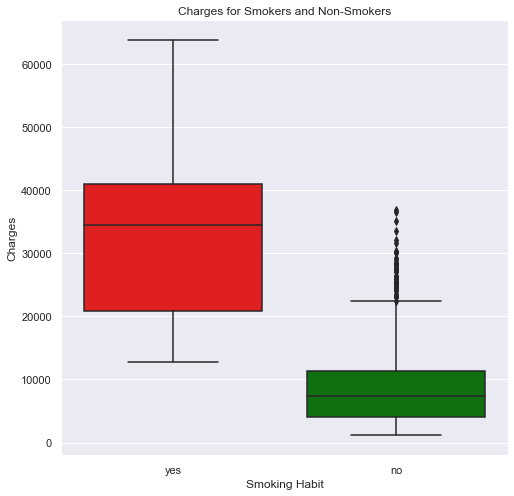

```python
sns.set(rc={"figure.figsize": (8, 8)});
sns.boxplot(x = "smoker", y = "charges", data = insurance,palette =['red','green']);
plt.title('Charges for Smokers and Non-Smokers');
plt.xlabel('Smoking Habit');
plt.ylabel('Charges');
```

The charges appear different for smokers and non-smokers. We proceed to see if this difference is statistically significant.

Let the random variable X1 denote the charges of smoker with mean μ1 and variance σ1-square

And the random variable X2 denote the charges of non-smokers with mean μ2 and variance σ2-square

### Null and Alternate Hypothesis

The null hypothesis is:

H0 : μ1 = μ2 (the charges of smokers and non-smokers do not vary significantly)

The alternate hypothesis is:

H1 : μ1 ≠ μ2 (the charges of smokers and non-smokers vary significantly)

### Defining Parameters

Let,

• x̄1 : mean charges of smoker group

• x̄2 : mean charges of non-smoker group

• S1 : SD of charges of smokers group

• S2 : SD of charges of non-smokers group

• n1 : sample size of smoker group

• n2 : sample size of non-smoker group

### Level of significance, test-statistic, Type of test and Degrees of Freedom

Here,

• The test is two sample t-test for independent samples

• We use level of significance as 5% i.e. α = 0.05

• This is a two-tailed test

• The degrees of freedom is n1+n2-2

### Assumptions

- The variances S1-sqaure and S2-square to be equal and the pooled variance is given by

$$Sp^2 = \frac{(n_1-1)*S_1^2+(n_2-1)*S_2^2}{n_1+n_2-2}$$

If we do not consider the assumption then we need to consider the Welch test.

- The population follow a normal distribution
- The data points are random and are independent of each other

**The test can be done by two methods:**

### 1. Critical Region Method

We compute the value of t-statistic where

$$ t-statistic = \frac{\bar{x1}-\bar{x2}}{\sqrt{\frac{S_p^2}{n_1}+\frac{S_p^2}{n_2}}} $$

and compare it with t_critical for α = 0.05 for two-tailed test and df = n1+n1-2 from tables.

**The rejection region is:**

t-statistic < -t_critical or t-statistic > t_critical

Under this condition we reject the null hypothesis and conclude that from given data the charges of smokers and non-smokers appear to be different.

### 2. p-value Method

We compute the p-value of the test. If the p-value is less than α (= 0.05) we reject the null hypothesis and conclude that from given data the charges of smokers and non-smokers appear to be different.

```python
# Deriving the required values to conduct the test based on critical region method

x1 = insurance[insurance['smoker'] == 'yes'].charges
x2 = insurance[insurance['smoker'] == 'no'].charges

x1_bar = x1.mean()
x2_bar = x2.mean()


n1 = len(x1.index)
n2 = len(x2.index)
dof=n1+n2-2

s1 = np.std(x1,ddof=1)
s2 = np.std(x2,ddof=1)

Sp_square = ((n1-1)*s1**2 + (n2-1)*s2**2)/(n1+n2-2)
t = (x1_bar-x2_bar)/sqrt((Sp_square/n1)+(Sp_square/n2))

t_critical = 1.96

print('Count, Mean and standard deviation of charges of smokers: %3d, %3.2f and %3.2f' % (n1, x1_bar,s1))
print('Count, Mean and standard deviation of charges of non-smokers: %3d, %3.2f and %3.2f' % (n2, x2_bar,s2))
print()
print('The calculated t-statistic is', round(t,4), 'and the t-critical at 0.05 level of significance for two-tailed test and',dof,'dof is',t_critical,'from tables')

print()

if -t_critical < t < t_critical:
    print("Since the test statistic lies in between the critical value points, we fail to reject the null hypothesis")
else:
    print("Since the test statistic lies in the rejection region, we reject the null hypothesis")
```

```
Count, Mean and standard deviation of charges of smokers: 274, 32050.23 and 11541.55
Count, Mean and standard deviation of charges of non-smokers: 1064, 8434.27 and 5993.78

The calculated t-statistic is 46.6649 and the t-critical at 0.05 level of significance for two-tailed test and 1336 dof is 1.96 from tables

Since the test statistic lies in the rejection region, we reject the null hypothesis
```

```python
# Deriving the required values to conduct the test

print('The mean charges for somkers and non-smokers are',round(x1.mean(),2),'and',round(x2.mean(),2),'respectively')
print()

t_stat, p_value = st.ttest_ind(x1, x2)

print('The t-statistic value is', round(t_stat,4),'and the p-value is', p_value)
print()

if p_value < 0.05:
    print("Since p-value is less than the level of significance, we reject the null hypothesis")
else:
    print("Since p-value is not less than the level of significance, we fail to reject the null hypothesis")
```

```
The mean charges for somkers and non-smokers are 32050.23 and 8434.27 respectively

The t-statistic value is 46.6649 and the p-value is 8.271435842177219e-283

Since p-value is less than the level of significance, we reject the null hypothesis
```

**We reject the null hypothesis and conclude that charges for smokers and non-smokers seem to differ significantly**

# Q4b. Does bmi of males differ significantly from that of females

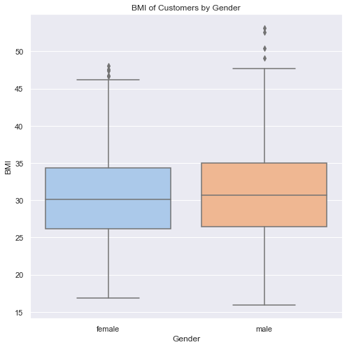

```python
sns.set(rc={"figure.figsize": (8, 8)});
sns.boxplot(x = "sex", y = "bmi", data = insurance,palette ='pastel');
plt.title('BMI of Customers by Gender');
plt.xlabel('Gender');
plt.ylabel('BMI');
```

There does not seem to be much difference between the BMI of males and females. We proceed to see if this is true statistically or not.

Let the random variable X1 denote the BMI of males with mean μ1 and variance σ1-square

And the random variable X2 denote the BMI of females with mean μ2 and variance σ2-square

### Null and Alternate Hypothesis

The null hypothesis is:

H0 : μ1 = μ2 (the BMI of males and females do not differ significantly)

The alternate hypothesis is:

H1 : μ1 ≠ μ2 (the BMI of males and females differ significantly)

### Defining Parameters

Let,

• x̄1 : mean BMI of males

• x̄2 : mean BMI of females

• S1 : SD of BMI of males

• S2 : SD of BMI of females

• n1 : sample size of males

• n2 : sample size of females

### Level of significance, test-statistic, Type of test and Degrees of Freedom

Here,

• The test is two sample t-test for independent samples

• We use level of significance as 5% i.e. α = 0.05

• This is a two-tailed test

• The degrees of freedom is n1+n2-2

### Assumptions

- The variances S1_square and S2_square to be equal and the pooled variance is given by

$$Sp^2 = \frac{(n_1-1)*S_1^2+(n_2-1)*S_2^2}{n_1+n_2-2}$$

If we do not consider the assumption then we need to consider the Welch test.

- The population follow a normal distribution
- The data points are random and are independent of each other

**The test can be done by two methods:**

### 1. Critical Region Method

We compute the value of t-statistic, where,

$$ t-statistic = \frac{\bar{x1}-\bar{x2}}{\sqrt{\frac{S_p^2}{n_1}+\frac{S_p^2}{n_2}}} $$

and compare it with t_critical for α = 0.05 for two-tailed test and df = n1+n1-2 from tables.

The **rejection region** is:

t-statistic < -t_critical or t-statistic > t_critical

Under this condition we reject the null hypothesis and conclude that from given data the BMI of males and females appear to be different.

### 2. p-value Method

We compute the p-value of the test. If the p-value is less than α (= 0.05) we reject the null hypothesis and conclude that from given data the BMI of males and females appear to be different.

```python
x1 = insurance[insurance['sex'] == 'male'].bmi
x2 = insurance[insurance['sex'] == 'female'].bmi


x1_bar = x1.mean()
x2_bar = x2.mean()


n1 = len(x1.index)
n2 = len(x2.index)
dof=n1+n2-2

s1 = np.std(x1,ddof=1)
s2 = np.std(x2,ddof=1)

Sp_square = ((n1-1)*s1**2 + (n2-1)*s2**2)/(n1+n2-2)
t = (x1_bar-x2_bar)/sqrt((Sp_square/n1)+(Sp_square/n2))

t_critical = 1.96

print('Count, Mean and standard deviation of BMI of males: %3d, %3.2f and %3.2f' % (n1, x1_bar,s1))
print('Count, Mean and standard deviation of BMI of females: %3d, %3.2f and %3.2f' % (n2, x2_bar,s2))

print()
print('The calculated t-statistic is', round(t,4), 'and the t-critical at 0.05 level of significance for two-tailed test and',dof,'dof is',t_critical,'from tables')

print()

if -t_critical < t < t_critical:
    print("Since the test statistic lies in between the critical value points, we fail to reject the null hypothesis")
else:
    print("Since the test statistic lies in the rejection region, we reject the null hypothesis")
```

```
Count, Mean and standard deviation of BMI of males: 676, 30.94 and 6.14
Count, Mean and standard deviation of BMI of females: 662, 30.38 and 6.05

The calculated t-statistic is 1.6968 and the t-critical at 0.05 level of significance for two-tailed test and 1336 dof is 1.96 from tables

Since the test statistic lies in between the critical value points, we fail to reject the null hypothesis
```

```python
print('The mean BMI of males and females are',round(x1.mean(),2),'and',round(x2.mean(),2),'respectively')
print()

t_stat, p_value = st.ttest_ind(x1, x2)

print('The t-statistic value is', round(t_stat,4),'and the p-value is', p_value)
print()

if p_value < 0.05:
    print("Since p-value is less than the level of significance, we reject the null hypothesis")
else:
    print("Since p-value is not less than the level of significance, we fail to reject the null hypothesis")
```

```
The mean BMI of males and females are 30.94 and 30.38 respectively

The t-statistic value is 1.6968 and the p-value is 0.08997637178984932

Since p-value is not less than the level of significance, we fail to reject the null hypothesis
```

**We fail to reject the null hypothesis and conclude that the BMI of males and females do not seem to differ significantly.**

# Q4c. Is the proportion of smokers significantly different in different genders

We want to see if the proportion of smokers in the two genders is significantly different

### Null and Alternate Hypothesis

The null hypothesis is:

H0 : p1 = p2 (the proportion of smokers in the two genders does not differ significantly)

The alternate hypothesis is:

H1 : p1 ≠ p2 (the proportion of smokers in the two genders differ significantly)

where p1 and p2 are proportion of smokers in males and females respectively

### Level of significance, test-statistic, Type of test

Here, we use the two-tailed test for test of proportion and choose level of significance as 5% ie α = 0.05

The test statistic is:

$$ Z = \frac{p1_{hat} - p2_{hat}}{\sqrt{p_0*(1-p_0)*(\frac{1}{n_1}+\frac{1}{n_2})}} $$

where

$$ p_0 = \frac{x_1+x_2}{n_1+n_2} $$

; x1 and x2 being the male and female smokers respectively and n1 and n2 being the total males and females respectively.

p1_hat and p2_hat are estimates of p1 and p2.

By **Critical Region Method** we reject null hypothesis if:

- Z< -Z_critical or Z > Z_critical. Here Z_critical is 1.96

and by **p-value Method** we reject null hypothesis if:

- p-value is less than 0.05

### Assumptions

- The data points are random and independent of each other

```python
x1 = insurance[insurance['sex'] == 'male'].smoker.value_counts()[1] # number of male smokers
x2 = insurance[insurance['sex'] == 'female'].smoker.value_counts()[1]  # number of female smokers

n1 = insurance.sex.value_counts()[0] #number of males in the data
n2 = insurance.sex.value_counts()[1]# number of females in the data
```

```python
p1_hat = x1 / n1
p2_hat = x2 / n2
print('Proportion of smokers in males:',round(p1_hat,2))
print('Proportion of smokers in females:',round(p2_hat,2))

p0 = (x1+x2)/(n1+n2)

Z = (p1_hat-p2_hat)/sqrt(p0*(1-p0)*(1/n1+1/n2))

print("test statistic =",Z)
```

```
Proportion of smokers in males: 0.24
Proportion of smokers in females: 0.17
test statistic = 2.7867402154855503
```

The value of test statistic lies in the rejection region. Hence we reject the null hypothesis.

```python
stat, pval = proportions_ztest([x1, x2] , [n1, n2])

print(pval)

if pval < 0.05:
    print(f'With a p-value of {round(pval,4)} the difference is significant. Hence we reject the null hypothesis')
else:
    print(f'With a p-value of {round(pval,4)} the difference is not significant. Hence we fail to reject the hypothesis')
```

```
0.005324114164320532
With a p-value of 0.0053 the difference is significant. Hence we reject the null hypothesis
```

**We reject the null hypothesis and conclude that the proportion of smokers seems to be significantly different in the two genders.**

# Q4d. Is the distribution of bmi across women with no children, one child and two children, the same?

```python
# Selecting data for female with no, 1 and 2 children

ins_anova = insurance[(insurance['children']<=2) & (insurance['sex']=='female')].copy()

x_c0 = ins_anova[ins_anova['children']==0].bmi
x_c1 = ins_anova[ins_anova['children']==1].bmi
x_c2 = ins_anova[ins_anova['children']==2].bmi

x_c0_bar = x_c0.mean()
x_c1_bar = x_c1.mean()
x_c2_bar = x_c2.mean()


n_c0 = len(x_c0.index)
n_c1 = len(x_c1.index)
n_c2 = len(x_c2.index)


s_c0 = np.std(x_c0,ddof=1)
s_c1 = np.std(x_c1,ddof=1)
s_c2 = np.std(x_c2,ddof=1)

print('Count, Mean and standard deviation of BMI of females with no children: %3d, %3.2f and %3.2f' % (n_c0, x_c0_bar,s_c0))
print('Count, Mean and standard deviation of BMI of females with 1 child: %3d, %3.2f and %3.2f' % (n_c1, x_c1_bar,s_c1))
print('Count, Mean and standard deviation of BMI of females with 2 children: %3d, %3.2f and %3.2f' % (n_c2, x_c2_bar,s_c2))
```

```
Count, Mean and standard deviation of BMI of females with no children: 289, 30.36 and 5.97
Count, Mean and standard deviation of BMI of females with 1 child: 158, 30.05 and 5.79
Count, Mean and standard deviation of BMI of females with 2 children: 119, 30.65 and 6.63
```

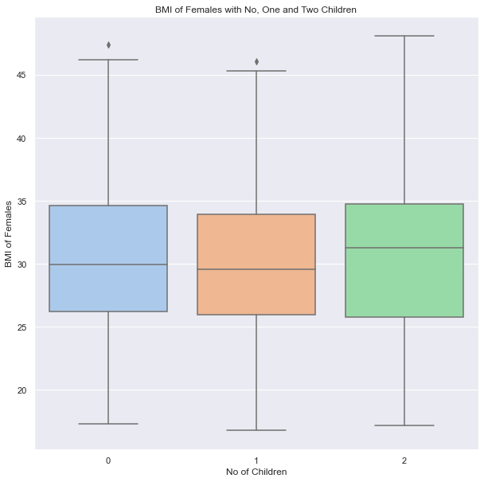

```python
sns.set(rc={"figure.figsize": (10, 10)});
sns.boxplot(x = "children", y = "bmi", data = ins_anova,palette='pastel');
plt.title('BMI of Females with No, One and Two Children');
plt.xlabel('No of Children');
plt.ylabel('BMI of Females');
```

The box-plot does not show much significant difference in BMI of females with 0,1 and 2 children. However, we proceed with the Analysis of Variance (ANOVA) to check statistically if there is any difference.

ANOVA is a hypothesis testing technique that tests the equality of more than two population means by examining the variances of samples that are taken.

## Assumptions

- All populations involved follow a normal distribution
- All populations have the same variance
- The data points are random and independent of one another

### Null and Alternate Hypothesis

H0 : 𝜇_c0 = 𝜇_c1 = 𝜇_c2

H1 : At least one 𝜇 differs

Here 𝜇_c0, 𝜇_c1 and 𝜇_c2 are the mean BMI of females with 0,1 and 2 children respectively.

### Level of Significance

We take here 5% level of significance i.e. α = 0.05

### Test Statistic

ANOVA uses F-tests to statistically test the equality of means.

### p-value

• statsmodels.formula.api.ols creates a model from a formula and dataframe

• statsmodels.api.sm.stats.anova_lm gives an Anova table for one or more fitted linear models

• The number PR(>F) gives the p-value. If p-value < level of significance we reject the null hypothesis

```python
mod = ols('bmi ~ children', data = ins_anova).fit()
aov_table = sm.stats.anova_lm(mod, typ=2)
print(aov_table)
```

```
                sum_sq     df         F   PR(>F)
children      2.512982    1.0  0.068411  0.79376
Residual  20717.738725  564.0       NaN      NaN
```

**Here the p-value is 0.79 which is more than 0.05. Hence we fail to reject the null hypothesis and conlcude that there is no significance difference of BMI of females with no, one or 2 children.**

## Summary and Recommendation

The given dataset captures the information of customer and medical costs of an insurance company. Below are some of the key-points from the analysis:

1. 79% of the customers are non-smokers. Gender-wise the number of customers is equally distributed. About 43% of the customers do not have a child.
1. Smoking habit and medical cost (given by the variable 'charges') have a strong relationship and smokers are billed higher than non-smokers. The difference in charges is statistically significant.

   Visually we saw that charges for smokers are higher than that of non-smokers. It is recommended to carry out test to check if charges for smokers are more than those of non-smokers. This would help the insurance company to strategise better
1. There is a weak positive relationship between age of customers and medical cost. The pattern is more prominent in individual clusters than overall. This could be due to some underlying factor. An example could be type of diseases. For treatment of same disease (D1) may cost more for older people than younger ones. However, for another disease (D2) the cost of treatment for younger people is more than the cost of treatment of older people with disease D1. An ailment history of customers may have added better insights.
1. The data has almost eqaul male and female customers. The BMI of males and females are not significantly different. However, the proportion of smokers in the two genders has a significant difference.
1. There is no statistical difference between BMI of women with 0,1 and 2 children.